# Log-log Regression

19-Oct-2020

## Still just linear regression

But now with log transformed data on the x and y axes

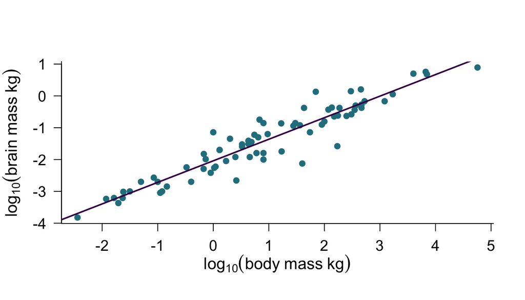

## Focus on length-mass relationships

- How does the mass of an organism scale with its length?
- Scaling is related to interesting biological and ecological processes
  - Metabolic costs
  - Transport of molecules over membranes
  - Predation or fishing / harvesting
  - Diet
  - Ecological scaling laws (abundance and biomass)

## Scaling of simple shapes

- How does a cube scale with its length?
- \(Mass = Density * Volume\)
- Assume density stays the same no matter what size, so \(Mass \propto Volume\)
- \(Volume = L_1 * L_2 * L_3\)
- \(Volume = a * L ^ b\)
- So if the cube stays the same shape (i.e. it remains a cube)
- How does mass change if length is doubled?
- \(Volume = 2L_1 * 2L_2 * 2L_3 = (2 * L) ^ 3 = 2^3 L^3\)
- Isometric scaling is when the object stays the same shape as it grows or shrinks

## Spherical cows

[figure not shown]

- How does mass of a sphere change with length?
- \(Volume = \frac{4}{3} * \pi * r ^ 3\)
- It is more normal to measure the length, not radius of an animal so…
- \(Volume = \frac{4}{3} * \pi * \frac{L^3}{2^3}\)
- \(Volume= \frac{4}{3} * \pi * (\frac{L}{2})^3 = \frac{4}{3*8} * \pi * L^3\)
- Again, \(Volume\), and hence \(Mass\) changes with \(Length^3\)
- So, generally \(Volume = (some ~ number) * L^3\)
- \(Volume = a * L ^ b\)
- Where for isometric scaling of \(Volume\) (or \(Mass\)) with \(Length\), \(b = 3\)

## A general equation for scaling of Mass to Length

- \(Mass = a * Length ^ b\)
- Take the Log of both sides (doesnt matter what logarithmic base)
- \(\log(M) = \log(a * L ^ b)\)
- \(\log(M) = \log(a) + \log(L^b)\)
- \(\log(M) = \log(a) + b * \log(L)\)
- which is the equation of a line
- \(Y = b_0 + b_1 * X\)
- where… \(\log(a) = b_0\)
- so… \(a = 10^{b_0}\) (assuming we are using logs in base 10)
- and… \(b_1 = b\) and is simply the power in the allometric equation

## What do these coefficients mean? - Intercept

[figure not shown]

- on a log-log scale what does the intercept mean?
- \(\log(M) = b_0 + b_1 * \log(L)\)
- the intercept is the coefficient, or multiplier of \(Length\)
- \(M = 10^{b_0} * Length ^ {b_1}\) (again assuming base 10)
- Recall that spheres and cubes only differ in their coefficients
- \(Volume_{cube} = [1] * L^3\)
- \(Volume_{sphere} = [\frac{4}{3*8} * \pi] * L^3\)
- So, \(b_0\) tells us that the shapes differ between two species

## What do these coefficients mean? - Slope

If the coefficient of \(\log_{10}(Length)\) is exactly 3, then the fish are growing isometrically and staying exactly the same shape. that is their width and depth is growing in proportion to their length.

[figure not shown]

## What do these coefficients mean? - Slope

If the coefficient of \(\log_{10}(Length)\) is less than 3, then the fish are putting on less mass than you would predict which means their width and/or depth is not increasing in proportion to their length and they are becoming thinner as they get longer.

[figure not shown]

## What do these coefficients mean? - Slope

If the coefficient of \(\log_{10}(Length)\) is greater than 3, then the fish are putting on more mass than you would predict which means their width and/or depth is not increasing in proportion to their length and they are becoming broader as they get longer.

[figure not shown]

## Mass - Length scaling in Finnish Fish

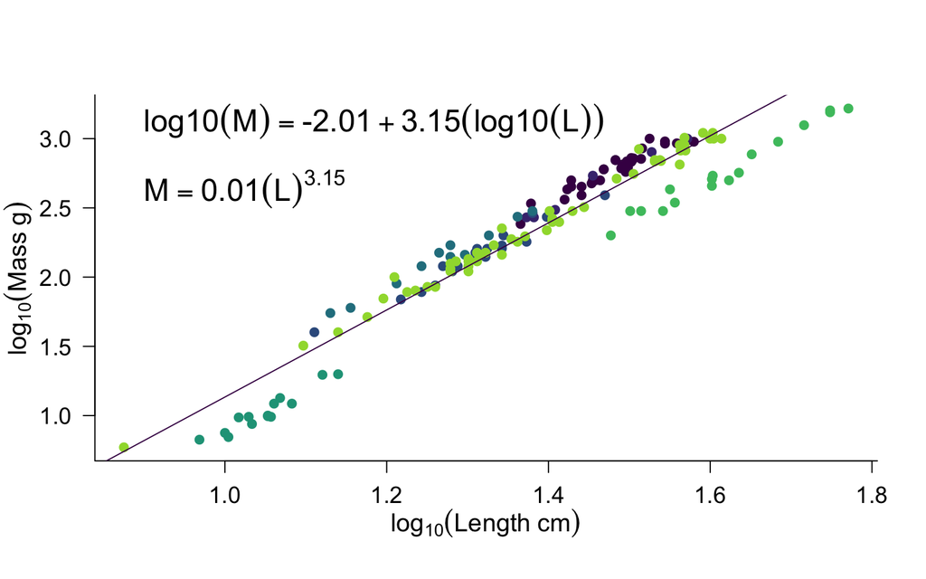

## Question

With a scaling relationship of \(Mass = 0.01 * Length ^ {3.15}\), is mass scaling:

1. Isometrically
2. Faster
3. Slower
- hint
- Isometric scaling for mass which is directly proportional to volume would be to power 3
- explanation
- 3.15 is larger than 3, so these fish are putting on more mass for a given length as they get larger.

## Exactly how much of an increase?

- This is just a linear equation
- \(\log_{10}(M) = -2.01 + 3.15 * \log_{10}(L)\)
- so a one unit increase in \(\log_{10}(L)\) leads to a 3.15 unit increase in \(\log_{10}(M)\)
- but these are in \(\log_{10}\) units…
- … and in raw terms means a proportional (multiplicative) increase.

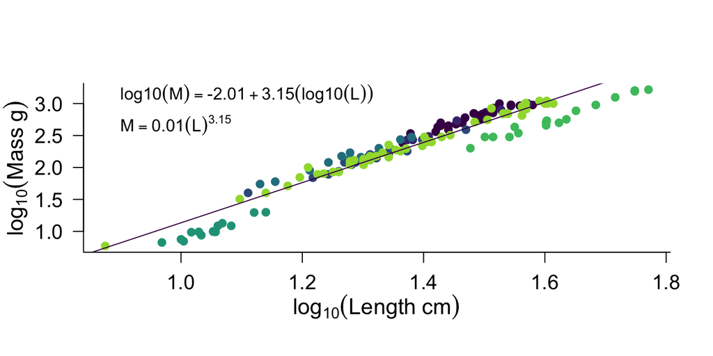

## Question

If \(\log_{10}(Length)\) increases by one unit, how much does \(Length\) increase by?

## Exactly how much of an increase?

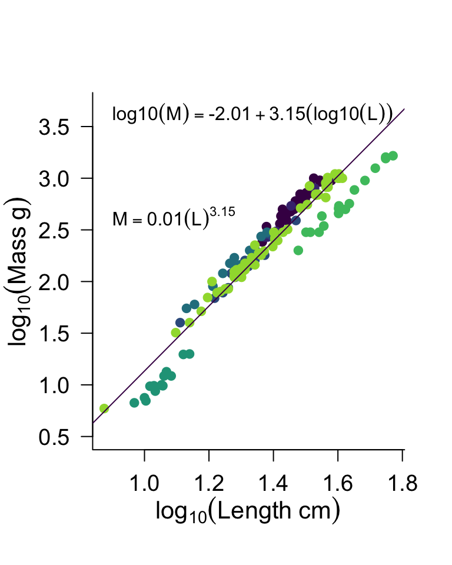

## Return to brain size evolution

[figure not shown]

## Brain - Body mass scatterplot

- Now we are not modelling \(Mass \sim Length\)
- but rather \(Mass \sim Mass\)

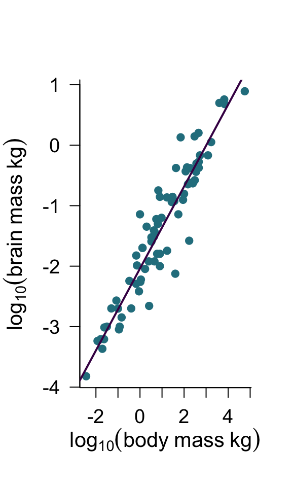

## Question

What exponent would we expect \(b\) to take in this equation if \(brain ~ mass\) scales isometrically with \(body ~ mass\)?

1. 0.66
2. 1
3. 2
4. 3

> -explanation + both brain and body mass are on the same scale, so we would expect them to grow with a scaling exponent of 1.

## Brain - Body mass scatterplot

- So, a sensible model is \(Mass_{brain} = a * Mass_{body} ^ 1\)
- which on \(\log_{10}\) transformed data would mean we expect the coefficient of \(\log_{10}(Mass_{body})\) to be \(1\).
- In reality, would you expect this value to be greater than, equal to, or less than \(1\)?
- what are the biological reasons that might govern this relationship?

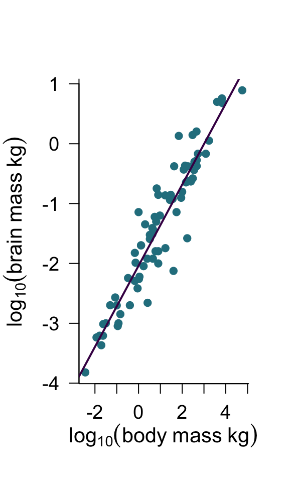

## Key learning outcomes

- Describe how change on a log scale affects the raw numbers
- Linearise the allometric equation using log transformations
- Use the equations fitted to data on log-log scale to make statements about proportional change in the response variable (y axis) as a function of proportional change in the covariates (x axis)